# COVID-19 Trend in BC

This is a breakdown of every confirmed or presumed COVID-19 case in BC over time. (source: https://www.ctvnews.ca/health/coronavirus/tracking-every-case-of-covid-19-in-canada-1.4852102)

Total cases as of March 19, 2020: 271  
Total deaths: 7

## Plot

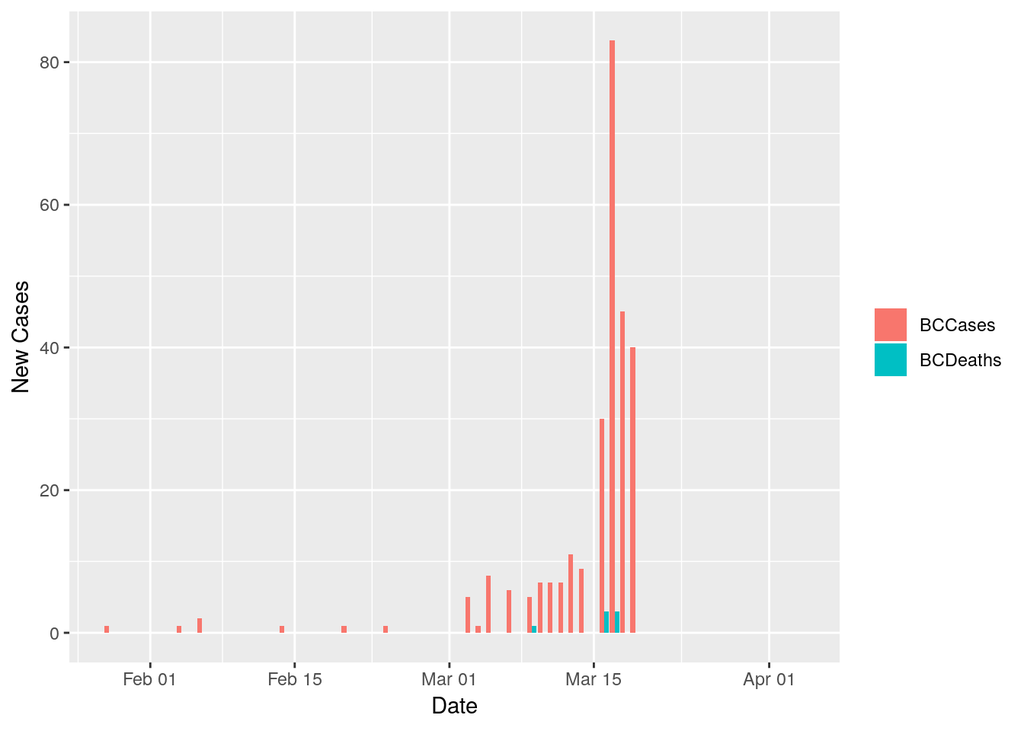

## Italy

Let’s compare this trend with Italy.

The population of Vancouver Metro is ~2.5M

The population of Italy is ~60.5M

Which gives us a ratio of 0.0413223 Vancouver to Italy

Using stats from https://www.worldometers.info/coronavirus/country/italy/, let’s see if we can find a time that Italy had a similar Daily New Case level.

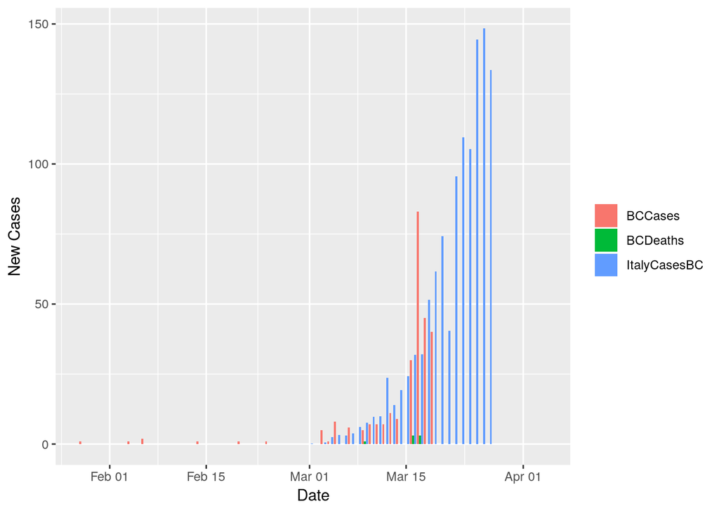

## Log Trend March 16th, 2020

Let’s take the raw data, perform a log transform, and then a linear fit We can then try to predict future numbers

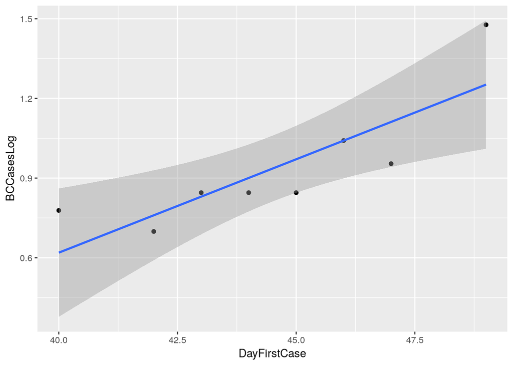

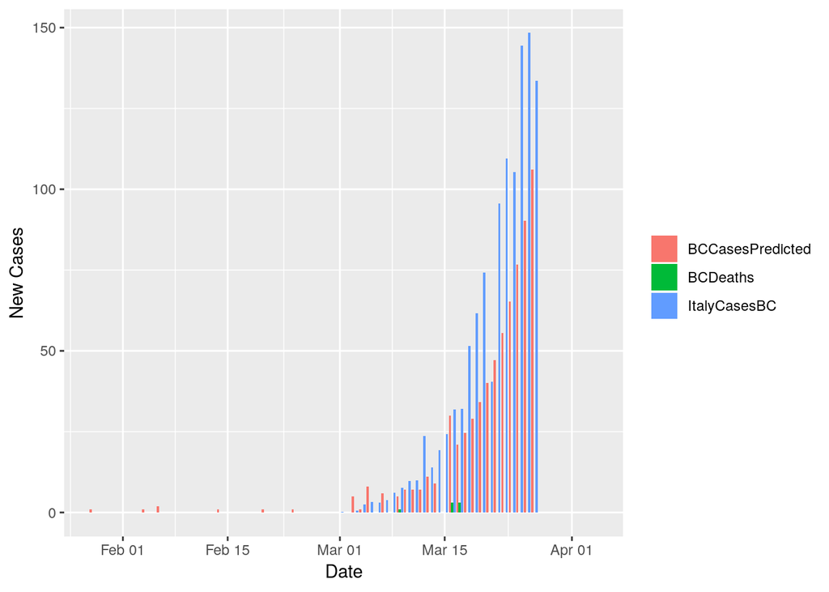

Given this, I would predict 21 new cases to be announced tomorrow (March 17th)

## Log Trend March 17th, 2020

Today it was announced there were 83 new cases  
And 3 new deaths  
Here is the new predictions

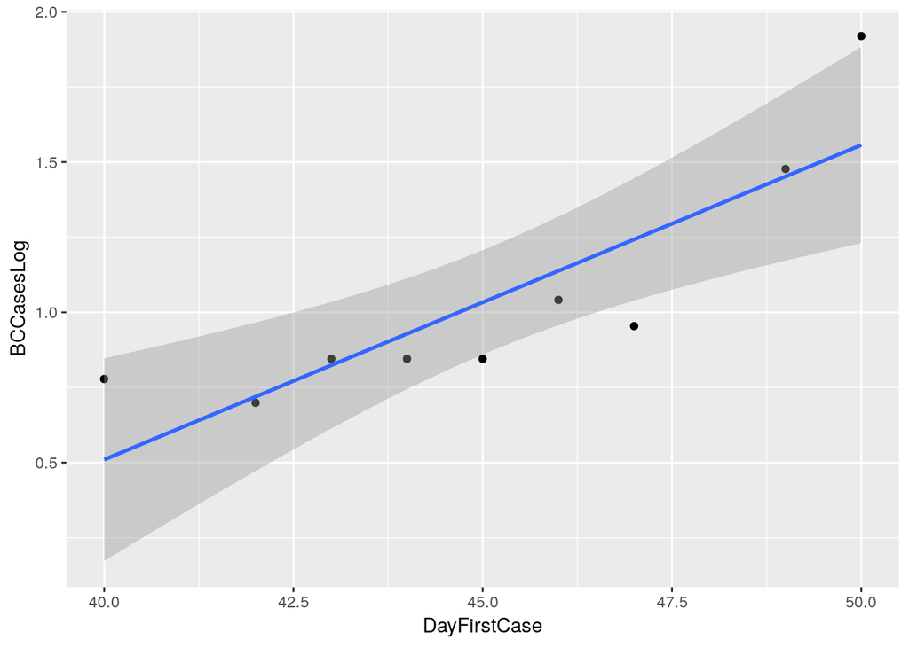

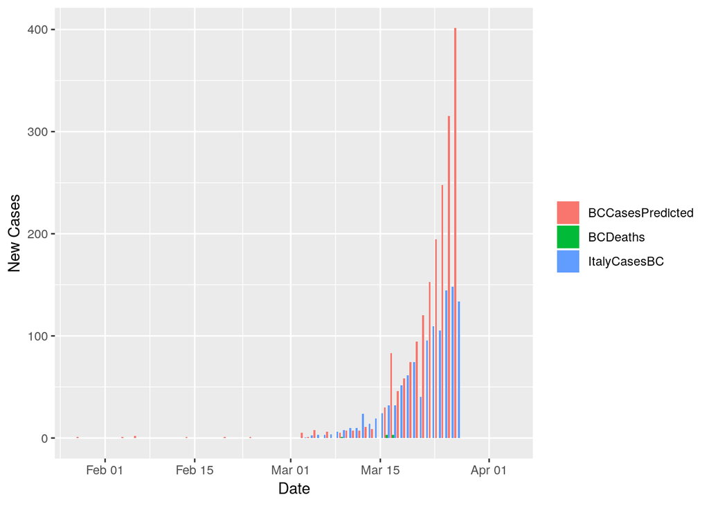

Given this, I would predict 46 new cases to be announced tomorrow (March 18th)

## Log Trend March 18th, 2020

Today it was announced there were 45 new cases  
And 0 new deaths  
Here is the new predictions

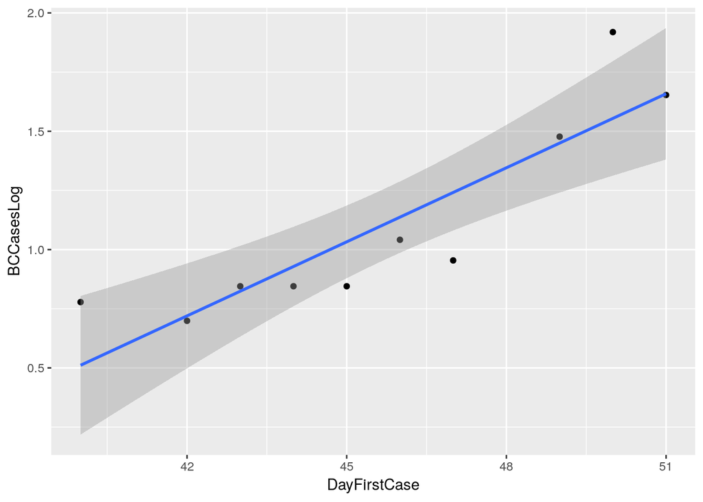

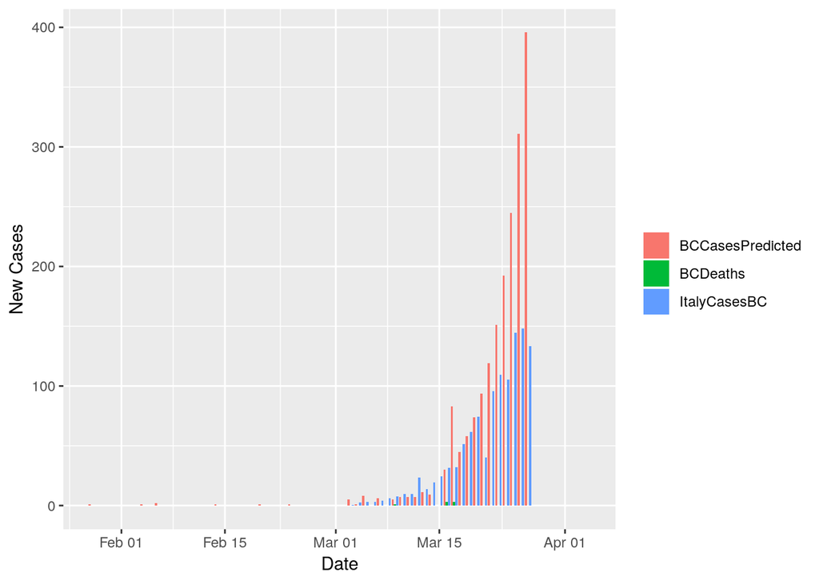

Given this, I would predict 58 new cases to be announced tomorrow (March 19th)

## Log Trend March 19th, 2020

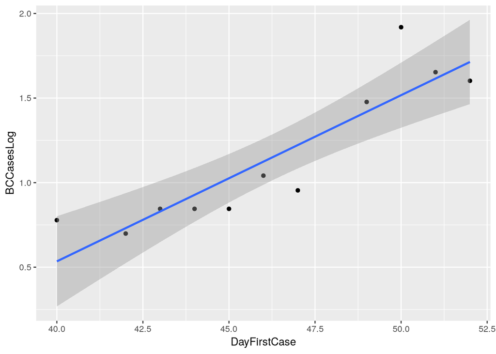

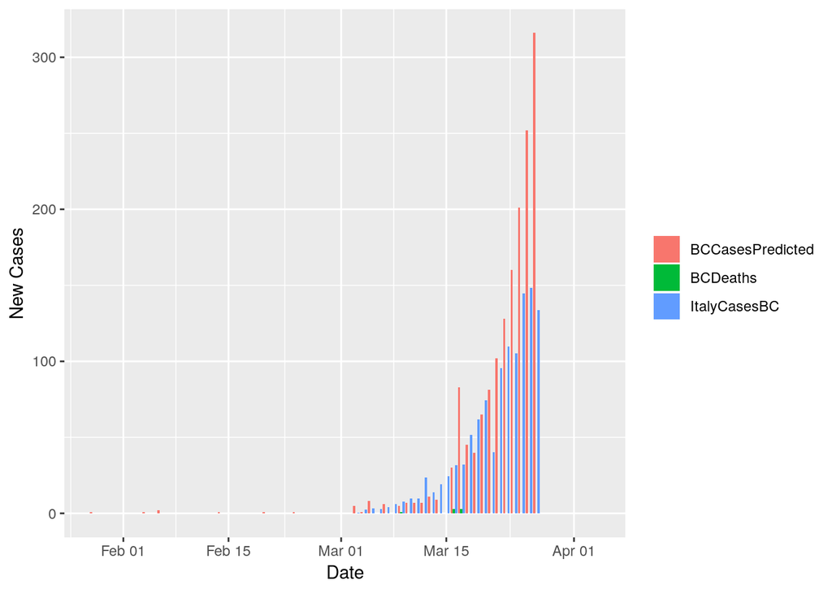

## Total Cases and a look at South Korea

South Korea currently is showing a normal distribution for daily new cases

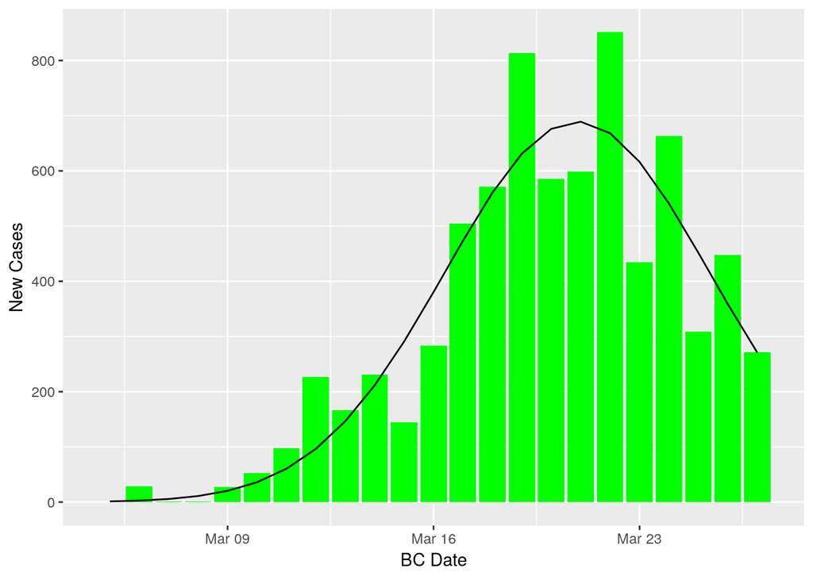

Let’s compare BC’s trend with SK.

The population of Vancouver Metro is ~2.5M

The population of South Korea is ~51.5M

Which gives us a ratio of 0.0485437 Vancouver to South Korea

Using stats from https://www.worldometers.info/coronavirus/country/south-korea/, let’s see if we can find a time that South Korea had a similar Daily New Case level.

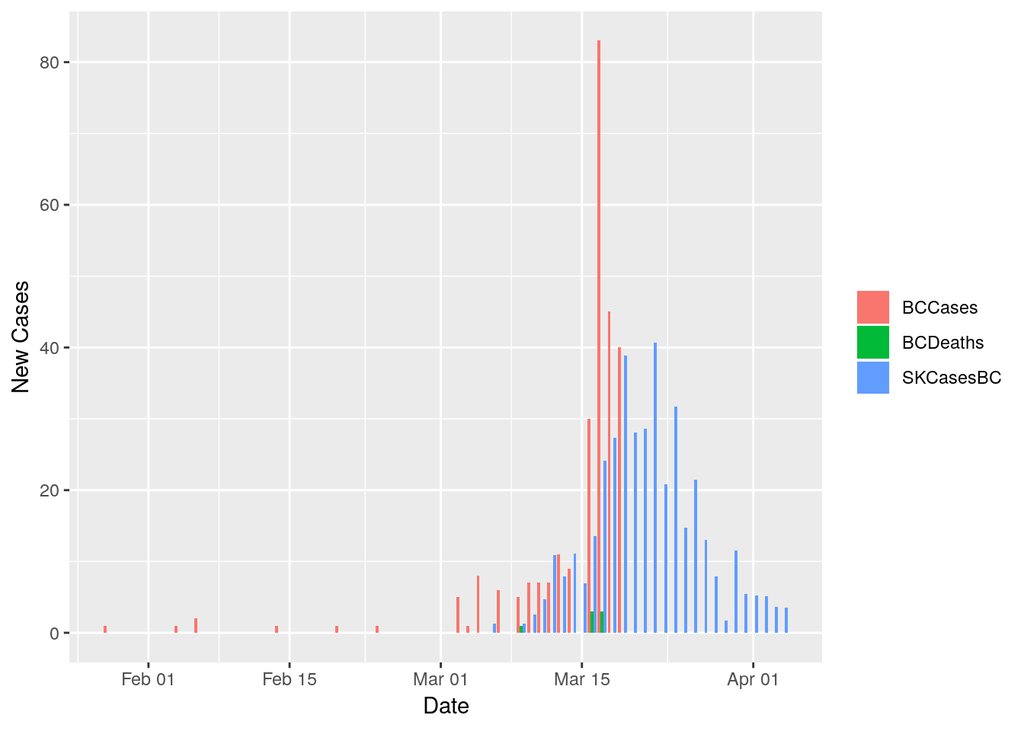

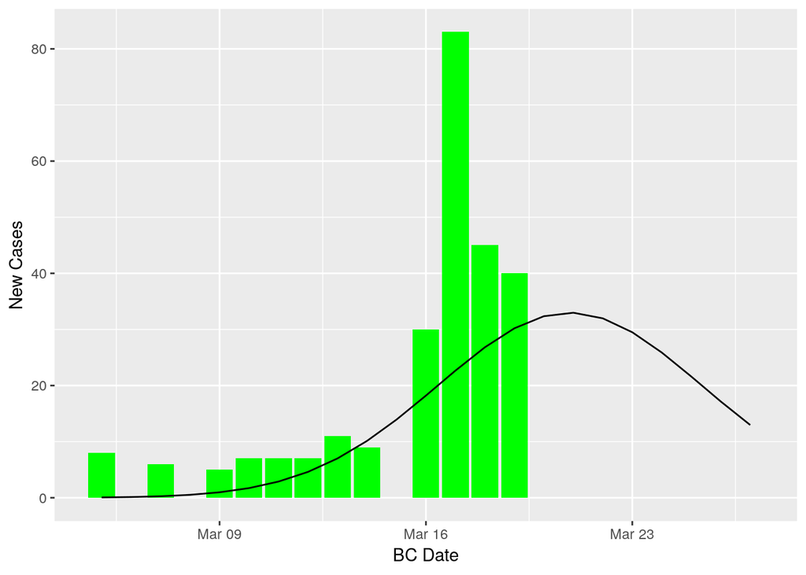